# Sentiment analysis part 1

```r
rm(list = ls())
```

```r
library(readr)
library(dplyr)
library(lubridate)
library(ggplot2)
library(zoo)
library(stringr)
library(purrr)
library(tidyr)

library(tidyverse)
library(stringi)

vax_sentiment <- read.csv("/Users/ssw107/Desktop/PhD/Wellcome Ideathon/EDA/The_Social_Scientists/data/vax_tweets_with_sentiment_entities_3.csv")
```

### Select only sentiment and text

```r
vax_sentiment <- vax_sentiment %>% dplyr::select(cleaned_text,
                                 polarity_text) %>%
                mutate(WordCount = stri_count_words(cleaned_text))
```

### separate negative sentiment and positive sentiment

Create a new data frame with only tweets whose sentiment value is less than 0

```r
vax_sentiment_negative <- filter(vax_sentiment, polarity_text <0)
vax_sentiment_positive <- filter(vax_sentiment, polarity_text >0)

nrow(vax_sentiment_negative)
nrow(vax_sentiment_positive)
```

[output not shown]

## Common topics

Now, we want to know what topics are most commonly contained within these tweets. There are two ways we can go about understanding this.

- The first is to look only at frequency. That is, which words are the most common?
- The second is to form topic clusters which show us which words are most associated with one another.

### First approach: Which words are the most common?

To do the first, finding the most frequent words, we need to begin by separating out each word. We will do this using the **quanteda** package. This is another text analysis package with a few simple tools to help us get the answers we want. After loading quanteda, we then use the **tokens()** command to separate out each word individually.

```r
library(quanteda)
vax_sentiment_tokenized_list <- tokens(vax_sentiment_negative$cleaned_text)
vax_sentiment_tokenized_list2 <- tokens(vax_sentiment_positive$cleaned_text)
```

```r
vax_sentiment_dfm <- dfm(vax_sentiment_tokenized_list)
vax_sentiment_dfm2 <- dfm(vax_sentiment_tokenized_list2)

word_sums <- colSums(vax_sentiment_dfm)
word_sums2 <- colSums(vax_sentiment_dfm2)
length(word_sums)
```

```
[1] 30356
```

```r
length(word_sums2)
```

```
[1] 65884
```

In order to then see which words are the most frequent, we create a new data frame from the “word_sums” values and order it by most common to least common words

```r
freq_data <- data.frame(word = names(word_sums),
                        freq = word_sums,
                        row.names = NULL,
                        stringsAsFactors = FALSE)

sorted_freq_data <- freq_data[order(freq_data$freq, decreasing = TRUE), ]

head(sorted_freq_data) #let's look at first 10 words
```

|  | word | freq |
| --- | --- | --- |
| 102 | the | 12913 |
| 25 | covidvaccine | 11089 |
| 6 | to | 8829 |
| 66 | of | 6033 |
| 8 | a | 5878 |
| 11 | and | 5327 |

```r
NA
```

```r
freq_data2 <- data.frame(word = names(word_sums2),
                        freq = word_sums2,
                        row.names = NULL,
                        stringsAsFactors = FALSE)

sorted_freq_data2 <- freq_data2[order(freq_data2$freq, decreasing = TRUE), ]

head(sorted_freq_data2) #let's look at first 10 words
```

|  | word | freq |
| --- | --- | --- |
| 38 | the | 37162 |
| 4 | covidvaccine | 36774 |
| 170 | to | 27266 |
| 49 | of | 17032 |
| 6 | for | 16982 |
| 84 | and | 16476 |

### Second approach: Topic clusters

```r
vax_sentiment_corpus_tm <- Corpus(VectorSource(vax_sentiment_negative[,1]))
vax_sentiment_dtm <- DocumentTermMatrix(vax_sentiment_corpus_tm)


vax_sentiment_corpus_tm2 <- Corpus(VectorSource(vax_sentiment_positive[,1]))
vax_sentiment_dtm2 <- DocumentTermMatrix(vax_sentiment_corpus_tm2)
```

We are uninterested in words which are so uncommon that they don’t appear in at least 2% of the documents–this is communicated by the complementary 0.98 threshold assigned to the removeSparseTerms() command.

```r
vax_sentiment_dtm <- removeSparseTerms(vax_sentiment_dtm, 0.98)
vax_sentiment_dtm2 <- removeSparseTerms(vax_sentiment_dtm2, 0.98)

vax_sentiment_cluster <- as.data.frame(as.matrix(vax_sentiment_dtm))
vax_sentiment_cluster2 <- as.data.frame(as.matrix(vax_sentiment_dtm2))
```

Create clusters using a technique called Exploratory Graph Analysis through EGAnet package. EGA is a form of network analysis which creates word clusters based on correlation. Words which are most correlated with one another will appear in the same cluster (also called a dimension) and it is up to the user to interpret these results.

```r
library(EGAnet)
library(sna)
```

#### Negative sentiment clusters

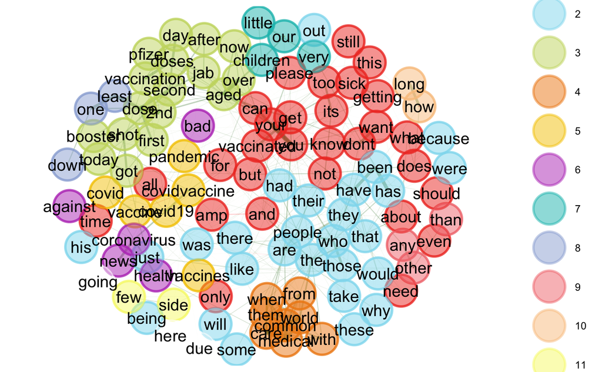

```r
ega_vax_sentiment <- EGA(vax_sentiment_cluster, cor = "spearman")
```

```r
ega_vax_sentiment$dim.variables
```

|  | items | dimension |
| --- | --- | --- |
| and | and | 1 |
| get | get | 1 |
| you | you | 1 |
| your | your | 1 |
| for | for | 1 |
| need | need | 1 |
| but | but | 1 |
| its | its | 1 |
| too | too | 1 |
| want | want | 1 |

[output cut: 99 more lines]

#### Positive sentiment clusters

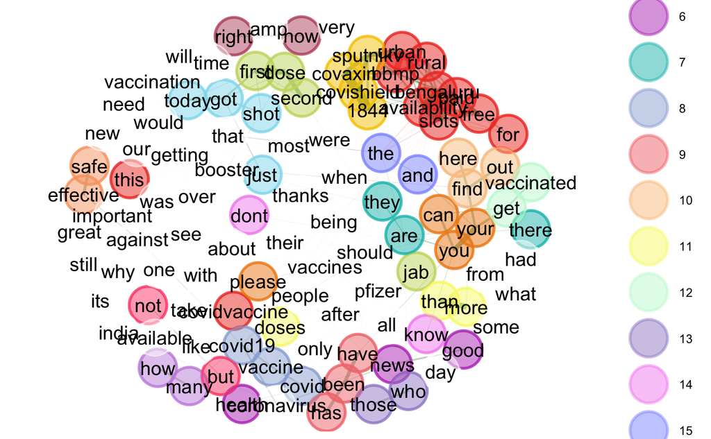

```r
ega_vax_sentiment2 <- EGA(vax_sentiment_cluster2, cor = "spearman")
```

```r
ega_vax_sentiment2$dim.variables
```

|  | items | dimension |
| --- | --- | --- |
| availability | availability | 1 |
| bengaluru | bengaluru | 1 |
| covidvaccine | covidvaccine | 1 |
| for | for | 1 |
| free | free | 1 |
| paid | paid | 1 |
| rural | rural | 1 |
| slots | slots | 1 |
| urban | urban | 1 |
| bbmp | bbmp | 1 |

[output cut: 98 more lines]